# assignment05

Jeff Nguyen

18/09/2020

**Regression Analysis on impact of COVID-19 on a 5-stock portfolio.**  
**Ngoc Son (Jeff) Nguyen**  
**University of Southern California**  
**Marshall School of Business**  
**FBE 506 Quantitative Method in Finance**  
**Fall 2020**  
**Directed by Professor Mohammad Safarzadeh**

# **Introduction**

We selected the following 5 securities to base our analysis of impact of COVID-19 on a CAPM model of 5 stocks upon.

| Ticker | Security | Sector | Industry | Founded | Full Time Employees |
| --- | --- | --- | --- | --- | --- |
| MSFT | Microsoft Corporation | Technology | Software-Infrastructure | 1975 | 163,000 |
| GWPH | GW Pharmaceuticals PLC | Healthcare | Drug Manufacturers-General | 1998 | 901 |
| DIS | The Walt Disney Company | Communication Services | Entertainment | 1923 | 223,000 |
| CAT | Caterpillar INC | Industrials | Farm & Heavy Construction Machinery | 1925 | 102,300 |
| AMZN | Amazon.com INC | Consumer Cyclical | Internet Retail | 1994 | 1,125,300 |

All information and data related to the securities are obtained from Yahoo Finance: MSFT, GWPH, DIS, CAT, and AMZN.

The objective of the study of the study is using the Modern Portfolio Theory to model a portfolio of five securities from different industries using adjusted closing price data from January 02, 2014 to December 31, 2018 to achieve the following:

1) Estimated the CAPM for the five securities portfolio.  
2) Understand the impact of COVID-19 on the alpha and market risk of the CAPM model.  
3) Compare the MPT portfolio to a similarly diversified portfolio (State Street’s SPDR S&P 500 Trust ETF).  
4) Use the CAPM model to forecast the returns on the portfolio.

# **Data Analysis**

## **1) Estimated the CAPM for the five securities portfolio**

### 1. Select at least five stocks from different industries (for the list of the firms in different industries see, https://biz.yahoo.com/p/sum_conameu.html).

```r
library(quantmod)
# Set start date and end date of data
start_date <- "2014-01-01"
end_date <- "2018-12-31"

# Get data
getSymbols("MSFT", src = "yahoo", from = start_date, to = end_date)
```

[output not shown]

```
## [1] "MSFT"
```

```r
getSymbols("GWPH", src = "yahoo", , from = start_date, to = end_date)
```

```
## [1] "GWPH"
```

```r
getSymbols("DIS", src = "yahoo", , from = start_date, to = end_date)
```

```
## [1] "DIS"
```

```r
getSymbols("CAT", src = "yahoo", , from = start_date, to = end_date)
```

```
## [1] "CAT"
```

```r
getSymbols("AMZN", src = "yahoo", , from = start_date, to = end_date)
```

```
## [1] "AMZN"
```

```r
getSymbols("^GSPC", src = "yahoo", , from = start_date, to = end_date) # S&P 500
```

```
## [1] "^GSPC"
```

```r
getSymbols("^TNX", src = "yahoo", from = start_date, to = end_date) # TNX (10-year T-bill)
```

```
## [1] "^TNX"
```

```r
# Adjusted Prices
adjMSFT <- MSFT$MSFT.Adjusted
adjGWPH <- GWPH$GWPH.Adjusted
adjDIS <- DIS$DIS.Adjusted
adjCAT <- CAT$CAT.Adjusted
adjAMZN <- AMZN$AMZN.Adjusted

# Get adjusted returns data
rMSFT <- diff(log(to.monthly(MSFT)$MSFT.Adjusted))
rGWPH <- diff(log(to.monthly(GWPH)$GWPH.Adjusted))
rDIS <- diff(log(to.monthly(DIS)$DIS.Adjusted))
rCAT <- diff(log(to.monthly(CAT)$CAT.Adjusted))
rAMZN <- diff(log(to.monthly(AMZN)$AMZN.Adjusted))
rGSPC <- diff(log(to.monthly(GSPC)$GSPC.Adjusted))
rTNX <- (to.monthly(TNX)$TNX.Adjusted) / 1200 # Using monthly rate
# Calculate statistics
MSFT_return_mean <- mean(rMSFT, na.rm = TRUE)
GWPH_return_mean <- mean(rGWPH, na.rm = TRUE)
DIS_return_mean <- mean(rDIS, na.rm = TRUE)
CAT_return_mean <- mean(rCAT, na.rm = TRUE)
AMZN_return_mean <- mean(rAMZN, na.rm = TRUE)
GSPC_return_mean <- mean(rGSPC, na.rm = TRUE)
TNX_return_mean <- mean(rTNX, na.rm = TRUE)

MSFT_return_var <- var(rMSFT, na.rm = TRUE)
GWPH_return_var <- var(rGWPH, na.rm = TRUE)
DIS_return_var <- var(rDIS, na.rm = TRUE)
CAT_return_var <- var(rCAT, na.rm = TRUE)
AMZN_return_var <- var(rAMZN, na.rm = TRUE)
GSPC_return_var <- var(rGSPC, na.rm = TRUE)

# Excess Returns
reMSFT <- rMSFT - rTNX
reGWPH <- rGWPH - rTNX
reDIS <- rDIS - rTNX
reCAT <- rCAT - rTNX
reAMZN <- rAMZN - rTNX

# Information Tables:
pricTabl <- data.frame(MSFT, GWPH, DIS, CAT, AMZN)

# Creates data frame of asset prices
retTabl <- data.frame(rMSFT, rGWPH, rDIS, rCAT, rAMZN)

# Creates data frame of returns
EretTabl <- data.frame(reMSFT, reGWPH, reDIS, reCAT, reAMZN)

# Excess return data frame
retTabl <- retTabl[-1,]  # remove missing data due to lagging
EretTabl <- EretTabl[-1,]  # remove missing data due to lagging
priceMat <- matrix(c(MSFT, GWPH, DIS, CAT, AMZN), nrow= length(MSFT), ncol=5, byrow=TRUE)  # creates a matrix of prices

# Variance/Covariance Matrix
asset.names <- c("MSFT", "GWPH", "DIS", "CAT", "AMZN")

# Create a list of row and col names for the var/cov matrix
VCV <- matrix(c(cov(retTabl)), nrow=5, ncol = 5, byrow=TRUE) # create a var/cov matrix by finding cov of the assets in retTab2
dimnames(VCV) <- list(asset.names, asset.names)  # assigns asset.names to the VCV matrix

#Calculate Returns
rm <- matrix(colMeans(retTabl, na.rm=TRUE))  # creates an average return matrix, omitting missing values
erm <- matrix(colMeans(EretTabl, na.rm=TRUE))  # creates an average excess return matrix, omitting missing values
tnxy = mean((rTNX)[-1,])  # calculates the average bond yield excluding Jan (risk free rate)

#Create Return Table
retmat <- matrix(c(rm, erm), ncol=2)
dimnames(retmat) = list(asset.names, c("Return ", "Excess Return"))
```

First we want to look at the data statistics

| Instruments | Mean Returns | Variance of Returns | Beta (5Y Monthly) |
| --- | --- | --- | --- |
| MSFT | 0.0185744 | 0.0035553 | .87 |
| GWPH | 0.0090021 | 0.0293563 | 1.96 |
| DIS | 0.0078206 | 0.0026173 | 1.08 |
| CAT | 0.0076711 | 0.0057854 | .98 |
| AMZN | 0.024 | 0.006961 | 1.3 |

Parameters of indices:

| Instruments | Mean Returns | Variance of Returns | Beta |
| --- | --- | --- | --- |
| S&P 500 | 0.0056356 | 0.0010169 | N/A |
| 10-Year T-bill | 0.0019378 | 0 | N/A |

We look at distribution of adjusted closing prices for each security:

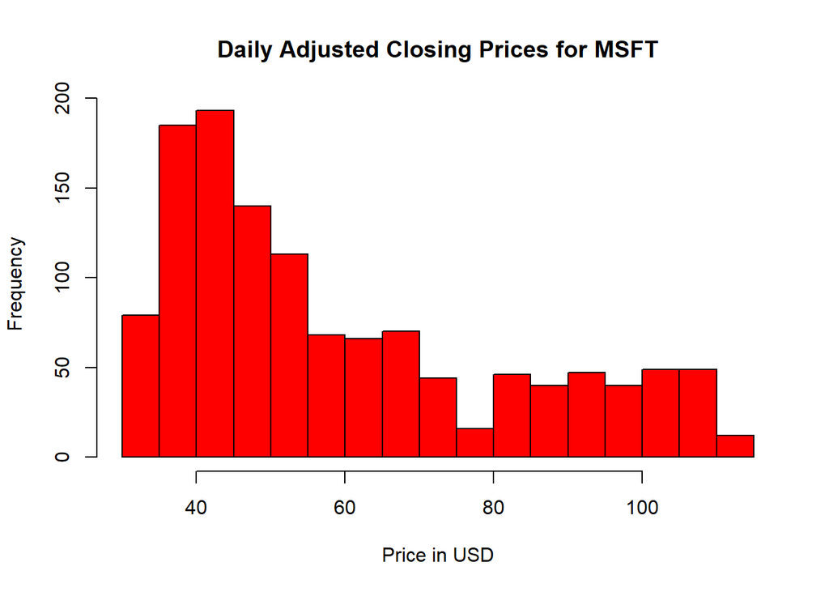

```r
hist(adjMSFT,
     main='Daily Adjusted Closing Prices for MSFT',
     xlab='Price in USD',
     col='red',
    )
```

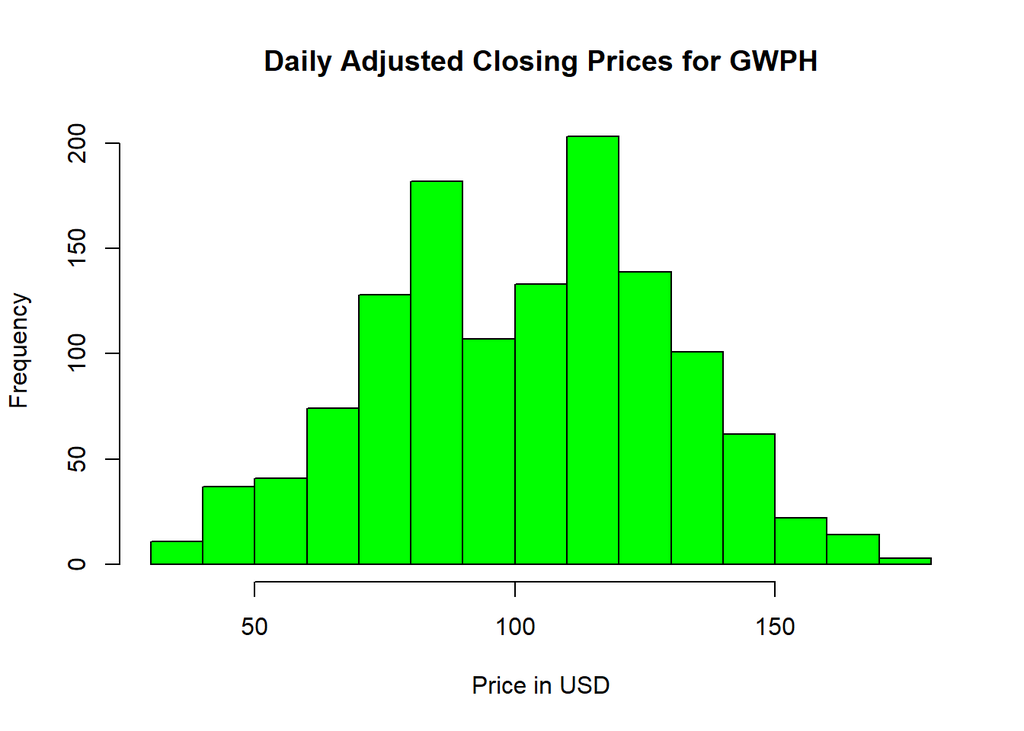

```r
hist(adjGWPH,
     main='Daily Adjusted Closing Prices for GWPH',
     xlab='Price in USD',
     col='green',
    )
```

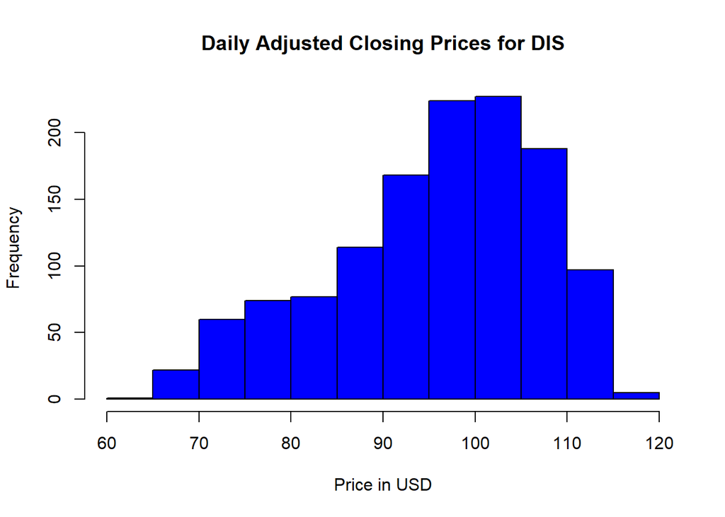

```r
hist(adjDIS,
     main='Daily Adjusted Closing Prices for DIS',
     xlab='Price in USD',
     col='blue',
    )
```

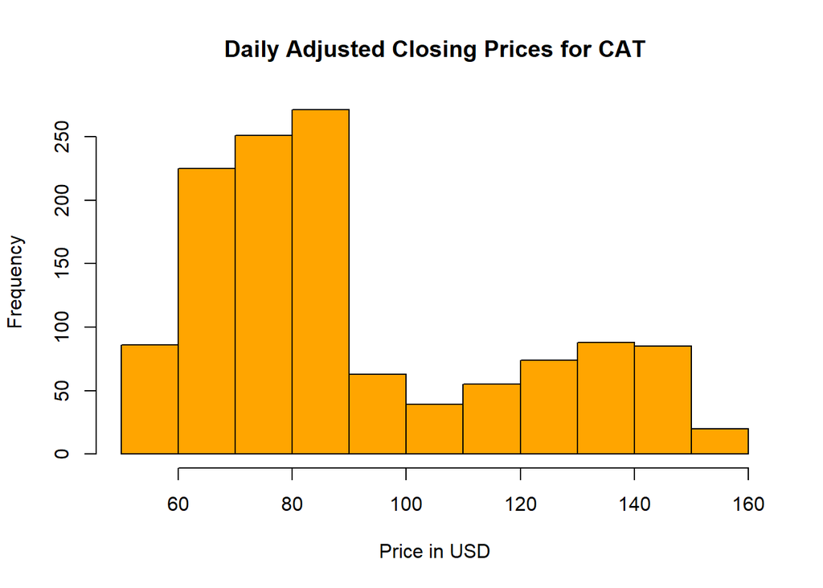

```r
hist(adjCAT,
     main='Daily Adjusted Closing Prices for CAT',
     xlab='Price in USD',
     col='orange',
    )
```

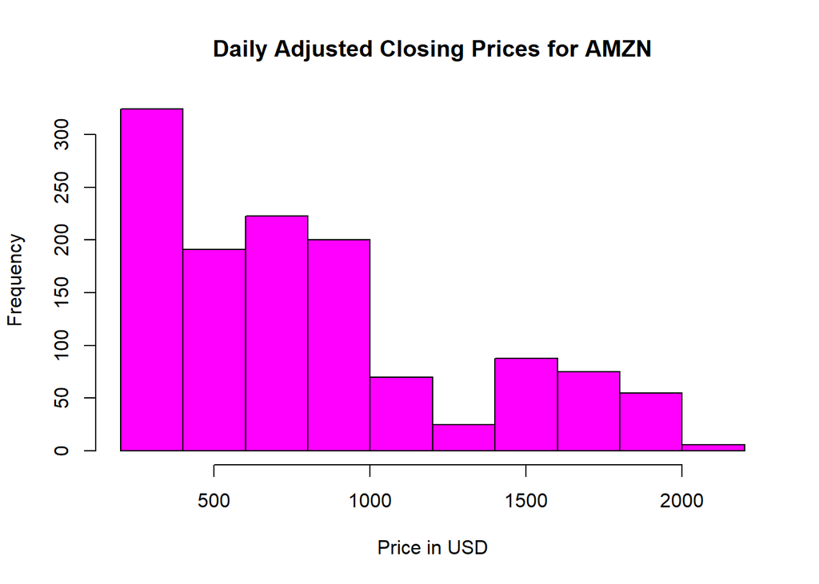

```r
hist(adjAMZN,
     main='Daily Adjusted Closing Prices for AMZN',
     xlab='Price in USD',
     col='magenta',
    )
```

## CAPM Portfolio Construction

Question covered: 2,3,4,5  
**Methodology**  
2a) Find the optimum weights using MPT.  
2b) Allocate $100.00 among the selected stocks using adjusted closing prices at 2018M12. 2019M1 will have a value of 100 as an index.  
2c) Using the adjusted closing prices from 2018M12 to 2020M8 calculate the holding values of the portfolio (assume fixed holdings with no re-balancing taking place over time).  
3) Find the tangency point of the Capital Allocation Line (CAL) and the efficient frontier.  
4) Calculate the CAL equation and graph CAL and the efficient frontier.  
5) Estimate CAPM for your portfolio and graph the estimated $\beta$ of the CAPM and the average return of your portfolio as a point relative to SML.

### 2a) Find the optimum weights using MPT

Since the investor’s objective is to minimize risk subjected to a minimum return of the risk free asset–US Treasury Bill, in this case–we solve the constrained optimization problem.  
Let $x_i$ denotes the weight of the investment in asset i $(i = 1,2,3,4,5)$, and assume all money is invested in i, meaning $\sum {x_i} = x_1 + x_2 + x_3 + x_4 + x_5 = 1$.

$$\begin{equation}
\begin{aligned}
\text {The returns of the portfolio is:} \\
R_{p,x} & = x_1 * r_1 + x_2 * r_2 + x_3 * r_3 + x_4 * r_4 + x_5 * r_5 \\
\text {The expected returns on the portfolio is:} \\
\mu_{p,x} & = E[R_{p,x}] \\
& = x_1 * \mu_1 + x_2 * \mu_2 + x_3 * \mu_3 + x_4 * \mu_4 + x_5 * \mu_5 \\
\text {The variance of the portfolio returns is:} \\
\sigma_{p,x}^2 & = var(R_{p,x}) \\
\end{aligned}
\end{equation}$$

Formulating the Markowitz portfolio problem:

$$\begin{equation}
\begin{aligned}
\text {The investor's objective is:} \\
max \quad \mu_p & = w' * \mu \quad \text{s.t.} \\
\sigma_p^2 & = w' * (\sum) * w \quad \text{and} \quad w'*I = 1 \\
\text {where:} \\
w & = \quad \text{matrix of asset weights in the portfolio} \\
w' & = \quad \text{transpose matrix of asset weights in the portfolio} \\
\mu & = \quad \text{matrix of mean returns of asset in the portfolio} \\
\sum & = \quad \text{Variance-covariance matrix of asset returns in the the portfolio} \\
w'*I & = \sum_{i=1}^{n} w_n \quad \text{or the sum weights of the asset in the portfolio, I is notation for identity matrix} \\
\end{aligned}
\end{equation}$$

Let $\mu_{p,0}$ denotes a target expected return level. Formulate the problem:

$$\begin{equation}
\begin{aligned}
min \quad \sigma_{p,w}^2 & = w' * (\sum) * w \quad \text{s.t.} \\
\mu_p & = w' * \mu = \mu_{p,0}, \quad \text{and} \quad w'*I = 1 \\
\end{aligned}
\end{equation}$$

To solve this, form the Lagrangian function:

$$\begin{equation}
\begin{aligned}
L(w, \lambda_1, \lambda_2) & = w'*\sum*w + \lambda_1*(w'*\mu - \mu_{p,0}) + \lambda_2*({w'*I - 1}) \\
\end{aligned}
\end{equation}$$

Because there are two constraints ($w'*\mu = \mu_{p,0}$ and $w'1 = 1$) there are two Langrange multipliers $\lambda_1$ and $\lambda_2$. The first order condition for a minimum are the linear equations:

$$\begin{equation}
\begin{aligned}
\frac{\partial L(w, \lambda_1, \lambda_2)}{\partial w} & = \frac{\partial (\sum * w^2)}{\partial w} + \frac{\partial (\lambda_1*(w'*\mu - \mu_{p,0}))}{\partial w} + \frac{\lambda_2*({w'*I - 1})}{\partial w} = 0 \\
\frac{\partial L(w, \lambda_1, \lambda_2)}{\partial \lambda_1} & = 0 \\
\frac{\partial L(w, \lambda_1, \lambda_2)}{\partial \lambda_2} & = 0 \\
\end{aligned}
\end{equation}$$

Simplify, we have:

$$\begin{equation}
\begin{aligned}
\frac{\partial L(w, \lambda_1, \lambda_2)}{\partial w} & = 2*\sum*w + \lambda_1*\mu + \lambda_2*I = 0 \\
\frac{\partial L(w, \lambda_1, \lambda_2)}{\partial \lambda_1} & = w'*\mu - \mu_{p,0} = 0 \\
\frac{\partial L(w, \lambda_1, \lambda_2)}{\partial \lambda_2} & = w'*I - 1 = 0 \\
\end{aligned}
\end{equation}$$

Rewrite in matrix form:

$$\begin{equation}
\begin{aligned}
\begin{pmatrix}
2*\sum & \mu & I \\
\mu' & 0 & 0 \\
I' & 0 & 0 \\
\end{pmatrix}
*
\begin{pmatrix}
w \\
\lambda_1 \\
\lambda_2 \\
\end{pmatrix}
& =
\begin{pmatrix}
0 \\
\mu_{p,0} \\
I \\
\end{pmatrix}
\end{aligned}
\end{equation}$$

or

$$\begin{equation}
\begin{aligned}
A * z_w & = b_0 \\
\text{where}\\
A & =
\begin{pmatrix}
2*\sum & \mu & I \\
\mu' & 0 & 0 \\
I' & 0 & 0 \\
\end{pmatrix} \\
z_w & =
\begin{pmatrix}
w \\
\lambda_1 \\
\lambda_2 \\
\end{pmatrix} \\
b_0 & =
\begin{pmatrix}
0 \\
\mu_{p,0} \\
I \\
\end{pmatrix}
\end{aligned}
\end{equation}$$

The solution for $z_w$ is:

$$\begin{equation}
\begin{aligned}
z_w & = A^{-1} * b_0
\end{aligned}
\end{equation}$$

The variance-covariance matrix is as follow:

```r
VCV
```

```
##             MSFT        GWPH         DIS         CAT        AMZN
## MSFT 0.003555316 0.001599836 0.001128235 0.002042991 0.002538589
## GWPH 0.001599836 0.029356292 0.002528779 0.005980634 0.005396791
## DIS  0.001128235 0.002528779 0.002617304 0.001243413 0.001405934
## CAT  0.002042991 0.005980634 0.001243413 0.005785368 0.002040476
## AMZN 0.002538589 0.005396791 0.001405934 0.002040476 0.006961024
```

The monthly risk-free rate is: $0.001933$

```r
# Optimum Portfolio
ZOPT <- solve(VCV,erm)  # multiply inverse of VCV to excess return to find z
WOPT <- ZOPT/sum(ZOPT)  # calculates weights
dimnames(WOPT) <- list(asset.names, "Weights") #label the weight matrix

# Calculate stats
ROPT <- t(WOPT)%*%rm  # calculate optimal portfolio's return
VOPT <- t(WOPT)%*%VCV%*%WOPT  # calculate optimal portfolio's variance
SDOPT <- VOPT^0.5  # calculate optimal portfolio's std dev
SRatio <-(ROPT-tnxy)/(SDOPT)  # calculate optimal portfolio's Sharpe ratio

# Create Optimal Stats Table
PTBL <- matrix(c(ROPT, VOPT, SDOPT, SRatio), nrow = 4)  # create a matrix of return, variance, std dev, Sharpe
optstat.names <- c("Return", "Variance", "Std Dev", "Sharpe")  # labels for PTBL matrix

dimnames(PTBL) <- list(optstat.names, "Opt. Portfolio")  # label the optimal portfolio matrix values
```

The optimal portfolio weights are as follow:

```r
WOPT
```

```
##          Weights
## MSFT  0.75172435
## GWPH -0.03902504
## DIS   0.01785490
## CAT  -0.18682397
## AMZN  0.45626977
```

The statistics of the optimal portfolio is:

```r
PTBL
```

```
##          Opt. Portfolio
## Return       0.02326846
## Variance     0.00436794
## Std Dev      0.06609039
## Sharpe       0.32282226
```

### 2b) Allocate $100.00 among the selected stocks using adjusted closing prices at 2018M12. 2019M1 will have a value of 100 as an index.

```r
# Set start date and end date of data
start_date1 <- "2018-12-01"
end_date1 <- "2020-08-31"

# Get data
getSymbols("MSFT", src = "yahoo", from = start_date1, to = end_date1)
```

```
## [1] "MSFT"
```

```r
getSymbols("GWPH", src = "yahoo", , from = start_date1, to = end_date1)
```

```
## [1] "GWPH"
```

```r
getSymbols("DIS", src = "yahoo", , from = start_date1, to = end_date1)
```

```
## [1] "DIS"
```

```r
getSymbols("CAT", src = "yahoo", , from = start_date1, to = end_date1)
```

```
## [1] "CAT"
```

```r
getSymbols("AMZN", src = "yahoo", , from = start_date1, to = end_date1)
```

```
## [1] "AMZN"
```

```r
getSymbols("^GSPC", src = "yahoo", , from = start_date1, to = end_date1) # S&P 500
```

```
## [1] "^GSPC"
```

```r
getSymbols("^TNX", src = "yahoo", from=start_date1, to=end_date1) # TNX (10-year T-bill)
```

```
## [1] "^TNX"
```

```r
rMSFT1 <- diff(log(to.monthly(MSFT)$MSFT.Adjusted))
rGWPH1 <- diff(log(to.monthly(GWPH)$GWPH.Adjusted))
rDIS1 <- diff(log(to.monthly(DIS)$DIS.Adjusted))
rCAT1 <- diff(log(to.monthly(CAT)$CAT.Adjusted))
rAMZN1 <- diff(log(to.monthly(AMZN)$AMZN.Adjusted))
rGSPC1 <- diff(log(to.monthly(GSPC)$GSPC.Adjusted))
rTNX1 <- to.monthly(TNX)$TNX.Adjusted /1200  # Using monthly rate
rTNX1 <- rTNX1[-1,]  # remove missing data due to lagging
mean_rTNX1 <- mean(rTNX1, na.rm=TRUE)

# Adjusted Prices
adjMSFT1 <- MSFT$MSFT.Adjusted
adjGWPH1 <- GWPH$GWPH.Adjusted
adjDIS1 <- DIS$DIS.Adjusted
adjCAT1 <- CAT$CAT.Adjusted
adjAMZN1 <- AMZN$AMZN.Adjusted

investedAmount <- 100

sharesMSFT <- as.numeric(investedAmount * WOPT[1] / adjMSFT1[1])
sharesGWPH <- as.numeric(investedAmount * WOPT[2] / adjGWPH1[1])
sharesDIS <- as.numeric(investedAmount * WOPT[3] / adjDIS1[1])
sharesCAT <- as.numeric(investedAmount * WOPT[4] / adjCAT1[1])
sharesAMZN <- as.numeric(investedAmount * WOPT[5] / adjAMZN1[1])

holdings <- data.frame("Holding Value"=sharesMSFT*adjMSFT1 +
                                       sharesGWPH*adjGWPH1 +
                                       sharesDIS*adjDIS1 +
                                       sharesCAT*adjCAT1 +
                                       sharesAMZN*adjAMZN1)
names(holdings)[1] <- "Port. Holdings Val"  # rename column
```

Based on the optimal weighting, to allocate $100 to the portfolio, we would be purchase the following amount of each security:

| Ticker | Weights | Stock to purchase |
| --- | --- | --- |
| MSFT | 0.7517244 | 0.6859734 |
| GWPH | -0.039025 | -0.0309109 |
| DIS | 0.0178549 | 0.0157364 |
| CAT | -0.186824 | -0.1424304 |
| AMZN | 0.4562698 | 0.0257436 |

### 2c) Using the adjusted closing prices from 2018M12 to 2020M8 calculate the holding values of the portfolio (assume fixed holdings with no re-balancing taking place over time).

We can then observe the fluctuations in the holding value of the portfolio from the period starting December 01 2018 to August 31, 2020 as follow.

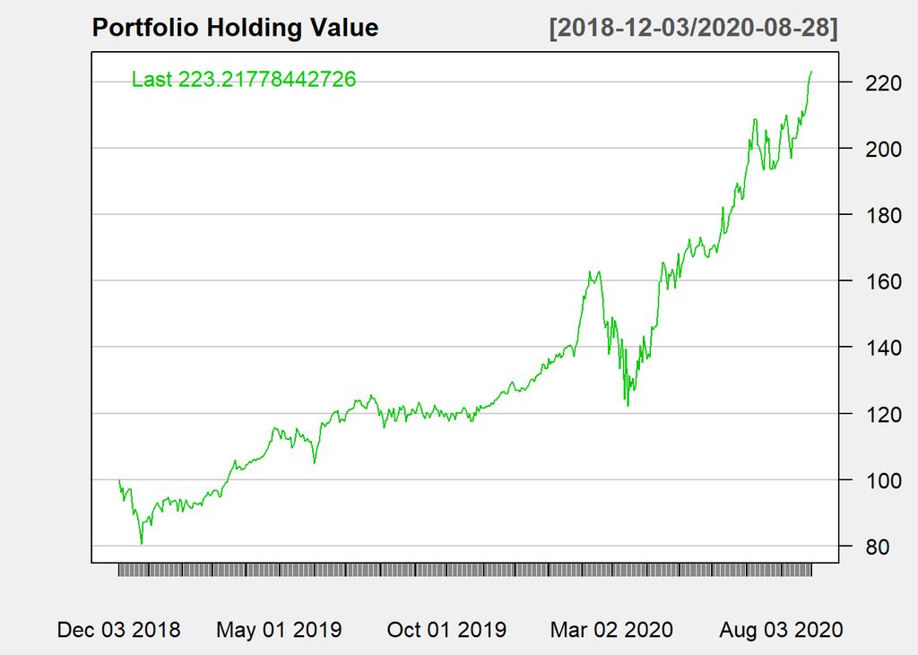

```r
chartSeries(holdings, name="Portfolio Holding Value", type="line", theme=chartTheme("white"))
```

By inspection we can see the portfolio experience a sharp sell off of almost 20% in December 2018, coincide with the broad U.S.market selloff due to a combination of the FED hiking the federal funds rate by 25 basis points to a targeted range of 2.25% to 2.5% (JeffCoxCNBCcom) and corporations followed suit by cutting profit forecasts and try temper expectations for earnings growth in 2019 after a big 2018 (Moyer).

The second visibly sharp sell off of the portfolio holding value also coincides with the broad market sell off in the mid March 2020 with investors raising cash in a risk-on environment when COVID-19 lockdowns started going into effects in the U.S.

### 3) Find the tangency point of the Capital Allocation Line (CAL) and the efficient frontier.

The tangency point of the Capital Allocation Line is the point where the weights of the portfolio is optimal, represented by the point $(\sigma_p, r_p)$ which is $(0.0660904, 0.0232685)$.

### 4) Calculate the CAL equation and graph CAL and the efficient frontier.

The efficient frontier is the portfolio possibility curve represented by the equation: $CAL = 0.001933 + 0.3228223 * \sigma_p$

```r
# Efficient Frontier and CAL
j <- 0  # set value for iterative loop variable t
return_p <- rep(0, 50000)
sd_p <- rep(0, 50000)

# create a matrix of 0 to fill later with sd of different weights
vect_0 <- rep(0, 50000)

# create a matrix of 0
fractions <- matrix(vect_0, 10000, 5)

# create a matrix of 0 to fill with weights
# iterate through weights for asset 1-5 from -20% to 100% by 10%
for (a in seq(-.2, 1, 0.1))
  {
  for (b in seq(-.2, 1, 0.1))
    {
    for (c in seq(-.2, 1, 0.1))
      {
      for (d in seq(-.2, 1, 0.1))
        {
        for (e in seq(-.2, 1, 0.1))
          {
          #test that the weights are equal to 1
          if (a+b+c+d+e==1)
            {
            # increment j by 1 if a+b+c+d+e is equal to 1 (valid weights)
            j=j+1
            # load a,b,c,d,e values into row j of the matrix
            fractions[j,] <- c(a,b,c,d,e)
            # calculate the std dev of the portfolio at a given weight of assets
            sd_p[j] <- (t(fractions[j,])%*%VCV%*%fractions[j,])^.5
            # calculate the return of the portfolio at a given weight of assets
            return_p[j] <- fractions[j,]%*%rm
            }
          }
        }
      }
    }
  }
# assign filled vector spots in return_p to the R_p matrix to omit empty spots
Rport <- return_p[1:j]

# assign filled vector spots in sd_p to the sigma_p matrix to omit empty spots
StdDev_p <- sd_p[1:j]

# Create Capital Asset Line
# Create x-coordinates for CAL points
f <- seq(0,.24, .24)

# Calculate corresponding y-coordinates
CAL <- tnxy + SRatio * f
```

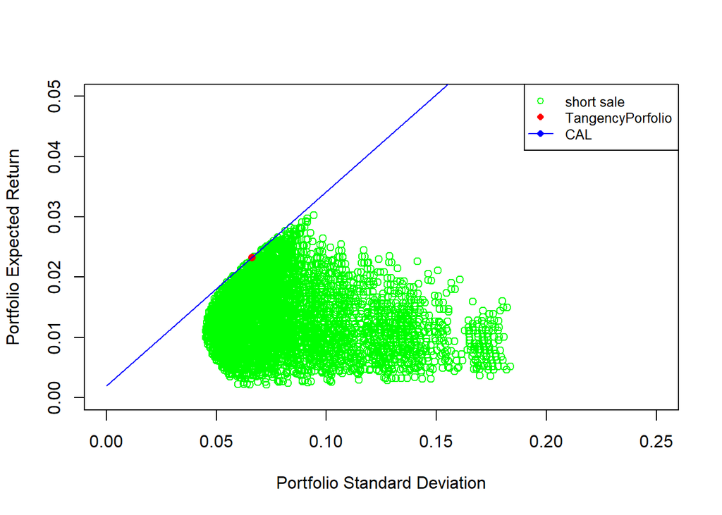

```r
#Plot the portfolio possibilities curve:
plot(StdDev_p, Rport, col="green1", xlab="Portfolio Standard Deviation", ylab= "Portfolio Expected Return", xlim=c(0, .25), ylim= c(0, .05))

#Plot of tangency point in red
points(SDOPT, ROPT, col= "red", pch=16, bg="red")

#Plot of CAL in blue
points(f, CAL, col= "blue", type="l")

legend("topright",c("short sale", "TangencyPorfolio", "CAL"), cex=.8, col=c("green1", "red","blue"),
       lty =c(0,0,1),pch=c(1,16,16))
```

### 5) Estimate CAPM for your portfolio and graph the estimated $\beta$ of the CAPM and the average return of your portfolio as a point relative to SML.

The expected risk premium of the portfolio based on the CAPM model is given as:

$$\begin{equation}
\begin{aligned}
E(R_a - R_f) & = \beta * (R_m - R_f) \\
\text{or} \\
R_a & = R_f + \beta * (R_m - R_f) \\
R_a - R_f & = \alpha_{Jensen} + \beta * (R_m - R_f) \\
\text{or} \\
Y & = \alpha_{Jensen} + \beta * X + epsilon \\
\text{with} \\
Y & = R_a - R_f \\
X & = R_m - R_f \\
\beta & = \text{Market risk or systematic risk} \\
\epsilon & = \text{stochastic error term} \\
\end{aligned}
\end{equation}$$

Here, the risk premium of the S&P 500 is the independent variable and the expected risk premium of the portfolio is the dependent variable.

Hypothesis for regression:
$$\begin{equation}
\begin{aligned}
H_0: \alpha & = 0 \\
H_a: \alpha & \neq 0 \\
\text{and} \\
H_0: \beta & = 0 \\
H_a: \beta & \neq 0 \\
\end{aligned}
\end{equation}$$

```r
# Calculate and normalized the CAPM holdings
ra <- diff(log(to.monthly(holdings)[,1]))

Y <- na.omit(ra - rTNX1)
names(Y)[1] <- "Portfolio Risk Premium"  # Rename column
Y_bar <- mean(Y)
Y_bar
```

```
## [1] 0.03515135
```

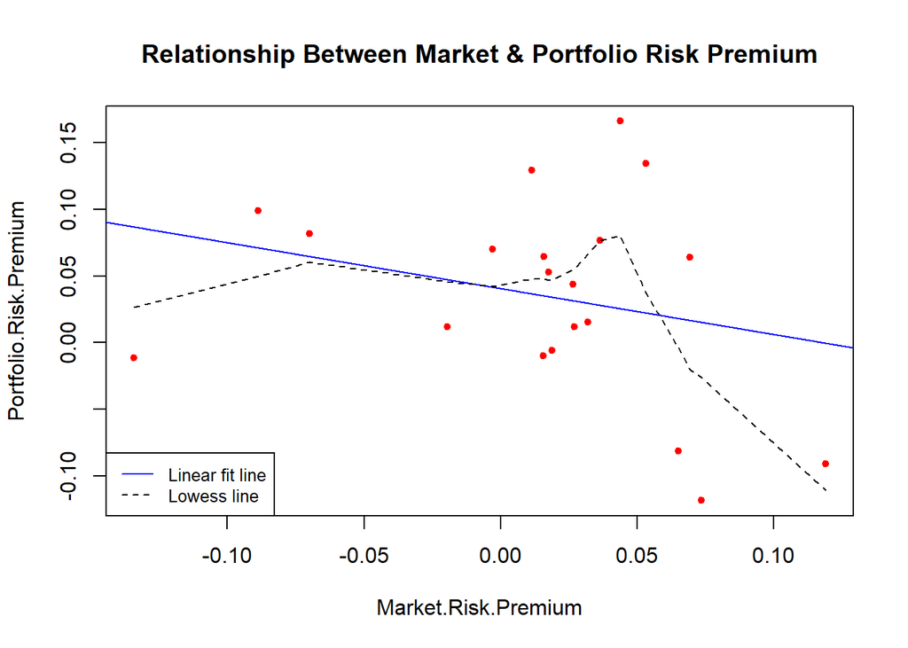

```r
X <- na.omit(rGSPC1 - rTNX1)
mean_X <- mean(X)

names(X)[1] <- "Market Risk Premium"  # Rename column
data1 <- data.frame(X, Y)

plot(data1, col='red', main="Relationship Between Market & Portfolio Risk Premium", pch=20, cex=1)

# Add fit lines
abline(lm(Y~X), col="blue")  # Regression line Y ~ X
lines(lowess(X,Y), col="black", lty=2)  # Lowess line (X,Y)

legend("bottomleft",c("Linear fit line", "Lowess line"), cex=.8, col=c("blue", "black"), lty=1:2)
```

Through inspection, we observe the cluster observation scattering in a big range from left to right. This implies a weak linear relationship between the Market Portfolio Risk Premium (the independent $X$ variable on the x-axis) and the CAPM Portfolio Risk Premium (the dependent $Y$ variable on the y-axis).

Next, we attempts to fit an equation of a line: $Y = \alpha_{Jensen} + \beta * X + \epsilon$

```r
fit1 <- lm(Y~X, data=data1)
summary(fit1)
```

```
##
## Call:
## lm(formula = Y ~ X, data = data1)
##
## Residuals:
##      Min       1Q   Median       3Q      Max
## -0.13365 -0.04123  0.01465  0.03414  0.14071
##
## Coefficients:
##             Estimate Std. Error t value Pr(>|t|)
## (Intercept)  0.04050    0.01728   2.343   0.0308 *
## X           -0.34504    0.29305  -1.177   0.2544
## ---
## Signif. codes:  0 '***' 0.001 '**' 0.01 '*' 0.05 '.' 0.1 ' ' 1
##
## Residual standard error: 0.07458 on 18 degrees of freedom
## Multiple R-squared:  0.07151,    Adjusted R-squared:  0.01992
## F-statistic: 1.386 on 1 and 18 DF,  p-value: 0.2544
```

Goodness of Fit:  
Through inspection, we observe the $R^2 = .07151$ value to not be close to 1 at all. $R^2 = .07151$ implies that $7.15%$ of the variations in the portfolio risk premium is explained by the market risk premium.

Thus, upon exploring the goodness of fit and standard error of regression, we confirm our initial observation that the portfolio risk premium and the market portfolio risk premium has a weak linear relationship.

The Security Market Line:

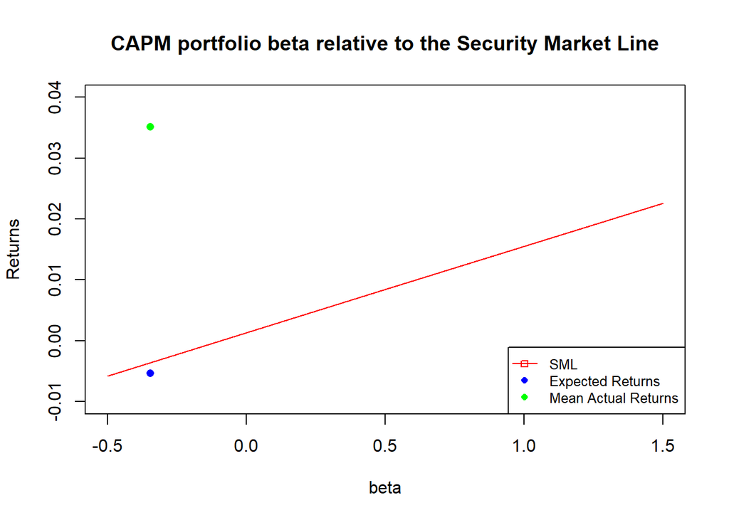

```r
# Generate the SML equation
slope_SML <- (mean_X - mean_rTNX1) / (1-0)
#slope_SML
SML <- function(beta) mean_rTNX1 + slope_SML * beta

# Plot the SML
beta <- seq(-.5, 1.5)
plot(beta, SML(beta), col="red", type="l", main="CAPM portfolio beta relative to the Security Market Line", xlab="beta", ylab="Returns", ylim=c(-.01, .04))

# Plot the expected returns
points(-.34504, -.34504*mean_X, col="blue", pch=16)

# Plot the average returns
points(-.34504, Y_bar, col="green", pch=16)

legend("bottomright",c("SML", "Expected Returns", "Mean Actual Returns"), cex=.8,
       col=c("red", "blue", "green"), lty=c(1,0,0), pch=c(0,16,16))
```

The Security Market Line pass through the point $(0, \overline {R_f})$ and $(1, \overline X)$, which are $(0, 0.0013135)$ and $(1, 0.0154876)$.  
Relative to its market risk of $beta = -.34504$, the expected return is $-0.0053439$ and the average return is $0.0351514$. We can observe that at this estimated $\beta$, the expected return is below the security market line and the actual average return is above the security market line.

## 6) Understand the impact of COVID-19 on the alpha and market risk of the CAPM model.

Question covered: 6).

**Methodology** Test whether the closing of the economy due to COVID-19 had any effect on Jensen alpha and the market risk of the CAPM model. (6)

We run regression for the model to see if the pandemic has any effect on Jensen alpha:

$$\begin{equation}
\begin{aligned}
Y & = \alpha_{Jensen} + \beta*X + \beta_1*D + \epsilon \\
\text{where: } \\
Y & = \, \text{Portfolio Risk Premium} \, R_a - R_f \\
\beta & = \, \text{Estimated} \, \beta \, \text{of the CAPM} \\
X & = \, \text{Market portfolio risk premium} \, R_m - R_f \\
\beta_1 & = \, \text{Coefficient representing the relationship of the portfolio risk premium with the pandemic factor} \\
D & = \, \text{Dummy variable representing the pandemic factor} \\
\epsilon & = \, \text{Standard Error of Regression} \\
\end{aligned}
\end{equation}$$

Hypothesis for regression:
$$\begin{equation}
\begin{aligned}
H_0: \alpha & = 0 \\
H_a: \alpha & \neq 0 \\
\text{and} \\
H_0: \beta_1 & = 0 \\
H_a: \beta_1 & \neq 0 \\
\end{aligned}
\end{equation}$$

We examine the potential relationship between the pandemic variable and the portfolio risk premium by plotting a scatter plot as follow:

```r
# Generating the dummy variable
D <- rep(0, 20)
D[15] <-1
D
```

```
##  [1] 0 0 0 0 0 0 0 0 0 0 0 0 0 0 1 0 0 0 0 0
```

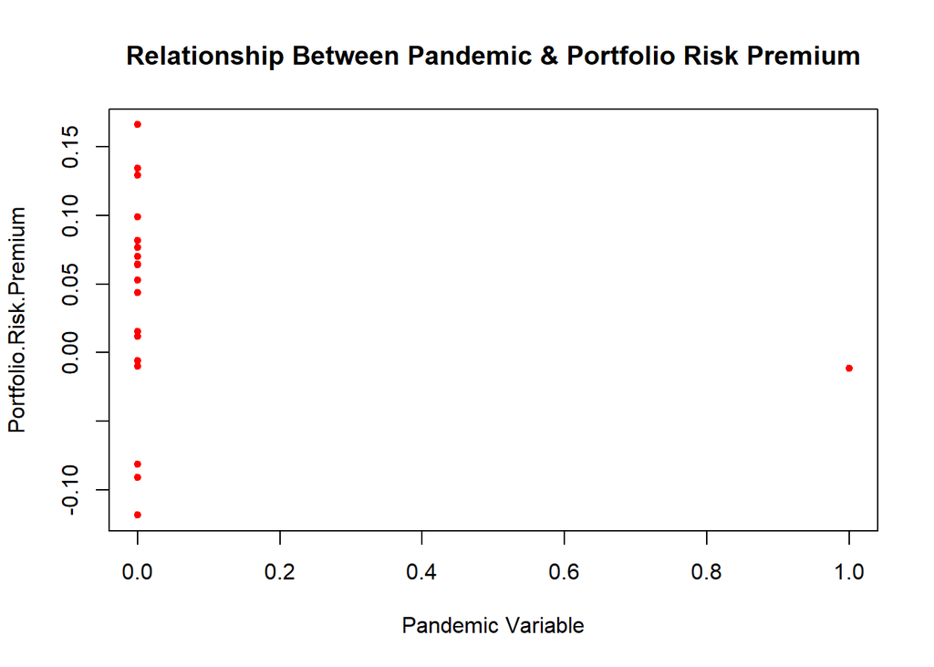

```r
data2 <- data.frame(D, Y)
names(data2)[1] <- "Pandemic Variable"

plot(data2, col='red', main="Relationship Between Pandemic & Portfolio Risk Premium", pch=20, cex=1)
```

Through inspection, we can see there is not much of a linear relationship between these variables.

Let’s assume linearity, we run regression on $Y = \alpha_{Jensen} + \beta*X + \beta_1*D$ as hypothesized above.

```r
fit2 <- lm(Y~X+D)
summary(fit2)
```

```
##
## Call:
## lm(formula = Y ~ X + D)
##
## Residuals:
##       Min        1Q    Median        3Q       Max
## -0.119935 -0.048422 -0.008044  0.028370  0.143203
##
## Coefficients:
##             Estimate Std. Error t value Pr(>|t|)
## (Intercept)  0.05447    0.01806   3.017  0.00778 **
## X           -0.72150    0.34667  -2.081  0.05284 .
## D           -0.16285    0.09052  -1.799  0.08979 .
## ---
## Signif. codes:  0 '***' 0.001 '**' 0.01 '*' 0.05 '.' 0.1 ' ' 1
##
## Residual standard error: 0.07034 on 17 degrees of freedom
## Multiple R-squared:   0.22,  Adjusted R-squared:  0.1282
## F-statistic: 2.398 on 2 and 17 DF,  p-value: 0.121
```

The estimated equation is $Y = .05447 - .72150*X - .16285*D$, where the $p_{value}$ for the intercept $.00778 < .05$.  
Therefore, we reject the null hypothesis at 95% confidence level that the intercept $\alpha_{Jensen}$ statistically is no different from zero. Thus, we reject the null hypothesis $H_0: \alpha = 0$ and accept the null hypothesis $H_a: \alpha \neq 0$.  
In addition, the coefficient $\beta_1 = -.16285$ represents the increase in portfolio risk premium relative to increase in the pandemic variable. The $p_{value}$ for $\beta_1$ is $.08979 > .05$, implying that the coefficient $\beta_1$ statistically is insignificant at 95% or more, and we accept the null hypothesis $H_0: \beta_1 = 0$ and reject the alternative hypothesis $H_a: \beta_1 \neq 0$.

Standard Error of Regression:
We can see that the Standard Error of Regression is $S.E. = .07034$.
From this, we can calculate the forecasting efficiency statistic to be:
$$\begin{equation}
\begin{aligned}
\frac{S.E.}{\overline Y} & = \frac{.07034}{0.0351514} \\
& = 200.11\% > 10\% \\
\end{aligned}
\end{equation}$$
This statistic implies that this is not a good forecasting model.

Now, we want to explore the affect of the pandemic lockdowns on market risk. Thus, we want to explore the following regression model:

$$\begin{equation}
\begin{aligned}
Y & = \alpha_{Jensen} + \beta*X + \beta_1*D + \beta_2*D*X +\epsilon_1 \\
\text{where: } \\
Y & = \, \text{Portfolio Risk Premium} \, R_a - R_f \\
\beta & = \, \text{Estimated} \, \beta \, \text{of the CAPM} \\
X & = \, \text{Market portfolio risk premium} \, R_m - R_f \\
\beta_1 & = \, \text{Coefficient representing the relationship of the portfolio risk premium with the pandemic factor} \\
D & = \, \text{Dummy variable representing the pandemic factor} \\
\beta_2 & = \, \text{Coefficient representing the relationship of the market risk premium with the pandemic factor} \\
D*X & = \, \text{Slope dummy variable representing the pandemic factor correlation with market risk premium} \\
\epsilon_1 & = \, \text{Standard Error of Regression} \\
\end{aligned}
\end{equation}$$

Hypothesis for regression:
$$\begin{equation}
\begin{aligned}
H_0: \alpha & = 0 \\
H_a: \alpha & \neq 0 \\
\text{and} \\
H_0: \beta_2 & = 0 \\
H_a: \beta_2 & \neq 0 \\
\end{aligned}
\end{equation}$$

```r
# Generate the new variable dx = D*X
DX <- D*X
fit3 <- lm(Y~X+D+DX)
summary(fit3)
```

```
##
## Call:
## lm(formula = Y ~ X + D + DX)
##
## Residuals:
##       Min        1Q    Median        3Q       Max
## -0.119935 -0.048422 -0.008044  0.028370  0.143203
##
## Coefficients: (1 not defined because of singularities)
##             Estimate Std. Error t value Pr(>|t|)
## (Intercept)  0.05447    0.01806   3.017  0.00778 **
## X           -0.72150    0.34667  -2.081  0.05284 .
## D           -0.16285    0.09052  -1.799  0.08979 .
## DX                NA         NA      NA       NA
## ---
## Signif. codes:  0 '***' 0.001 '**' 0.01 '*' 0.05 '.' 0.1 ' ' 1
##
## Residual standard error: 0.07034 on 17 degrees of freedom
## Multiple R-squared:   0.22,  Adjusted R-squared:  0.1282
## F-statistic: 2.398 on 2 and 17 DF,  p-value: 0.121
```

We see $\beta_2 = NA$ implying that the slope dummy is an unnecessary predictor. The coefficient $\beta_2$ is not estimated.

Let’s run the regression with the slope dummy separately, so the equation of the regression becomes:

$$\begin{equation}
\begin{aligned}
Y & = \alpha_{Jensen} + \beta*X + \beta_2*D*X +\epsilon_2 \\
\text{where: } \\
Y & = \, \text{Portfolio Risk Premium} \, R_a - R_f \\
\beta & = \, \text{Estimated} \, \beta \, \text{of the CAPM} \\
X & = \, \text{Market portfolio risk premium} \, R_m - R_f \\
D & = \, \text{Dummy variable representing the pandemic factor} \\
\beta_2 & = \, \text{Coefficient representing the relationship of the market risk premium with the pandemic factor} \\
D*X & = \, \text{Slope dummy variable representing the pandemic factor correlation with market risk premium} \\
\epsilon_1 & = \, \text{Standard Error of Regression} \\
\end{aligned}
\end{equation}$$

Again, stating the hypothesis for regression:
$$\begin{equation}
\begin{aligned}
H_0: \alpha & = 0 \\
H_a: \alpha & \neq 0 \\
\text{and} \\
H_0: \beta_2 & = 0 \\
H_a: \beta_2 & \neq 0 \\
\end{aligned}
\end{equation}$$

```r
# Generate the new variable dx = D*X
fit4 <- lm(Y~X+DX)
summary(fit4)
```

```
##
## Call:
## lm(formula = Y ~ X + DX)
##
## Residuals:
##       Min        1Q    Median        3Q       Max
## -0.119935 -0.048422 -0.008044  0.028370  0.143203
##
## Coefficients:
##             Estimate Std. Error t value Pr(>|t|)
## (Intercept)  0.05447    0.01806   3.017  0.00778 **
## X           -0.72150    0.34667  -2.081  0.05284 .
## DX           1.21306    0.67427   1.799  0.08979 .
## ---
## Signif. codes:  0 '***' 0.001 '**' 0.01 '*' 0.05 '.' 0.1 ' ' 1
##
## Residual standard error: 0.07034 on 17 degrees of freedom
## Multiple R-squared:   0.22,  Adjusted R-squared:  0.1282
## F-statistic: 2.398 on 2 and 17 DF,  p-value: 0.121
```

Standard Error of Regression:
We can see that the Standard Error of Regression is $S.E. = .07034$.
From this, we can calculate the forecasting efficiency statistic to be:
$$\begin{equation}
\begin{aligned}
\frac{S.E.}{\overline Y} & = \frac{.07034}{0.0351514} \\
& = 200.11\% > 10\% \\
\end{aligned}
\end{equation}$$
This statistic implies that this is not a good forecasting model.

To visualize:

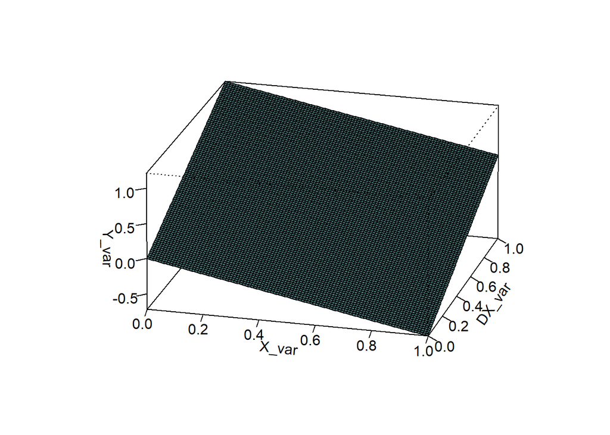

```r
X_var <- seq(0,1,.01)
DX_var <- X_var
f <- function(X, DX) {fit4$coefficient[2]*X + fit4$coefficient[3]*DX}
Y_var <- outer(X_var, DX_var, f)
persp(X_var, DX_var, Y_var, col="cadet blue",
      theta=15, phi=20, r=50, d=0.1, expand=0.5, ltheta=90, lphi=20, shade=0.75, ticktype="detailed", nticks=5)
```

## 3) Compare the CAPM portfolio to a diversified State Street’s SPDR S&P 500 Trust ETF portfolio (7,8,9)

Questions covered: 7,8,9.

**Methodology**  
7) Calculate CV, Sharpe, Treynor, and Sortino ratios for your portfolio and compare them to a similarly diversified portfolio of Vanguard, Fidelity, or any other similar portfolio.  
8) Calculate 2% and 3% VaRs as a percentage of the mean return of your portfolio when the risk horizon is one year, six months, and one month. Calculate the same VaRs for the selected portfolio in item 6. Compare the VaRs of your portfolio to the ones of the market portfolios.  
9) Graph the scatter diagram of your portfolio and comment on trends, outliers, structural breaks and any other special features. Graph the scatter diagram of your portfolio and S&P 500 on the same coordinate system and compare the trends.

### 7) Calculate CV, Sharpe, Treynor, and Sortino ratios for your portfolio and compare them to a similarly diversified portfolio of Vanguard, Fidelity, or any other similar portfolio.

```r
# Calculate statistics
MSFT1_return_mean <- mean(rMSFT1, na.rm = TRUE)
GWPH1_return_mean <- mean(rGWPH1, na.rm = TRUE)
DIS1_return_mean <- mean(rDIS1, na.rm = TRUE)
CAT1_return_mean <- mean(rCAT1, na.rm = TRUE)
AMZN1_return_mean <- mean(rAMZN1, na.rm = TRUE)
GSPC1_return_mean <- mean(rGSPC1, na.rm = TRUE)
TNX1_return_mean <- mean(rTNX1, na.rm = TRUE)

MSFT1_return_var <- var(rMSFT1, na.rm = TRUE)
GWPH1_return_var <- var(rGWPH1, na.rm = TRUE)
DIS1_return_var <- var(rDIS1, na.rm = TRUE)
CAT1_return_var <- var(rCAT1, na.rm = TRUE)
AMZN1_return_var <- var(rAMZN1, na.rm = TRUE)
GSPC1_return_var <- var(rGSPC1, na.rm = TRUE)

# Excess Returns
reMSFT1 <- rMSFT1 - rTNX1
reGWPH1 <- rGWPH1 - rTNX1
reDIS1 <- rDIS1 - rTNX1
reCAT1 <- rCAT1 - rTNX1
reAMZN1 <- rAMZN1 - rTNX1

# Information Tables:
#pricTabl1 <- data.frame(MSFT, GWPH, DIS, CAT, AMZN)

# Creates data frame of asset prices
retTabl1 <- data.frame(rMSFT1, rGWPH1, rDIS1, rCAT1, rAMZN1)

# Creates data frame of returns
EretTabl1 <- data.frame(reMSFT1, reGWPH1, reDIS1, reCAT1, reAMZN1)

# Excess return data frame
retTabl1 <- retTabl1[-1,]  # remove missing data due to lagging
EretTabl1 <- EretTabl1[-1,]  # remove missing data due to lagging
priceMat1 <- matrix(c(MSFT, GWPH, DIS, CAT, AMZN), nrow= length(MSFT), ncol=5, byrow=TRUE)  # creates a matrix of prices

# Variance/Covariance Matrix
asset.names <- c("MSFT", "GWPH", "DIS", "CAT", "AMZN")

# Create a list of row and col names for the var/cov matrix
VCV1 <- matrix(c(cov(retTabl1)), nrow=5, ncol = 5, byrow=TRUE) # create a var/cov matrix by finding cov of the assets in retTab2
dimnames(VCV1) <- list(asset.names, asset.names)  # assigns asset.names to the VCV matrix

#Calculate Returns
rm1 <- matrix(colMeans(retTabl1, na.rm=TRUE))  # creates an average return matrix, omitting missing values
erm1 <- matrix(colMeans(EretTabl1, na.rm=TRUE))  # creates an average excess return matrix, omitting missing values
tnxy1 = mean((rTNX1)[-1,])  # calculates the average bond yield excluding Jan (risk free rate)

#Create Return Table
retmat1 <- matrix(c(rm1, erm1), ncol=2)
dimnames(retmat1) = list(asset.names, c("Return ", "Excess Return"))

# Calculate stats
ROPT1 <- t(WOPT)%*%rm1  # calculate optimal portfolio's return
VOPT1 <- t(WOPT)%*%VCV1%*%WOPT  # calculate optimal portfolio's variance
SDOPT1 <- VOPT1^0.5  # calculate optimal portfolio's std dev
SRatio1 <-(ROPT1-tnxy1)/(SDOPT1)  # calculate optimal portfolio's Sharpe ratio

mean_Holdings1 <- as.numeric(colMeans(holdings[1]))  # Mean
sd_Holdings1 <- as.numeric(sqrt(var(holdings)))
CV1 <- sd_Holdings1 / mean_Holdings1   # calculate portfolio's coefficient of variation

TrRatio1 <- (ROPT1 - tnxy1)/ -0.34504  # calculate portfolio's Treynor Ratio

# Calculating downside deviation using lower partial moment of order 2
mar <- tnxy1  # Assuming the 10 year T-bill returns as minimum acceptable returns MAR
rHoldings <- diff(log(holdings[,1]))  # calculate portfolio holding returns data
dev_rHoldings_mar <- na.omit(rHoldings - mar)  # Deviation from MAR, this is a data frame, remove NA values
devNegative_rHoldings_mar <- subset(dev_rHoldings_mar, dev_rHoldings_mar < 0)  # Get the subset of negative values
downsideDev_Holdings <- var(devNegative_rHoldings_mar)  # Calculate the Lower Partial Moment
sd_downsideDev_Holdings <- sqrt(downsideDev_Holdings)  # Downside deviation

SoRatio1 <- (ROPT1 - tnxy1) / sd_downsideDev_Holdings  # calculate portfolio Sortino Ratio

# Create Optimal Stats Table
PTBL1 <- matrix(c(CV1, SRatio1, TrRatio1, SoRatio1), nrow = 4)  # create a matrix of return, variance, std dev, Sharpe
optstat.names <- c("CV", "Sharpe", "Treynor", "Sortino")  # labels for PTBL matrix

dimnames(PTBL1) <- list(optstat.names, "Holdings")  # label the optimal portfolio matrix values
```

```r
# Get data
getSymbols("SPY", src = "yahoo", from = start_date1, to = end_date1)
```

```
## [1] "SPY"
```

```r
rSPY1 <- na.omit(diff(log(to.monthly(SPY)$SPY.Adjusted)))
mean_rSPY1 <- mean(rSPY1)
var_rSPY1 <- var(rSPY1)
sd_rSPY1 <- sqrt(var_rSPY1)

adjSPY1 <- SPY$SPY.Adjusted
mean_adjSPY1 <- mean(adjSPY1)
var_adjSPY1 <- var(adjSPY1)
sd_adjSPY1 <- sqrt(var_adjSPY1)

SRatioSPY1 <-(mean_rSPY1-tnxy1) / sd_rSPY1  # calculate optimal portfolio's Sharpe ratio
CVSPY1 <- sd_adjSPY1 / mean_adjSPY1  # calculate portfolio's coefficient of variation
TrRatioSPY1 <- (mean_rSPY1 - tnxy1)/ 1  # calculate portfolio's Treynor Ratio

# Calculating downside deviation using lower partial moment of order 2
marSPY1 <- tnxy1  # Assuming the 10 year T-bill returns as minimum acceptable returns MAR
dev_rSPY1_mar <- na.omit(rSPY1 - mar)  # Deviation from MAR, this is a data frame, remove NA values
devNegative_rSPY1_mar <- subset(dev_rSPY1_mar, dev_rSPY1_mar < 0)  # Get the subset of negative values
downsideDev_SPY1 <- var(devNegative_rSPY1_mar)  # Calculate the Lower Partial Moment
sd_downsideDev_SPY1 <- sqrt(downsideDev_SPY1)  # Downside deviation

SoRatioSPY1 <- (mean_rSPY1 - tnxy1) / sd_downsideDev_SPY1  # calculate portfolio Sortino Ratio

# Create Optimal Stats Table
SPYTBL1 <- matrix(c(CVSPY1, SRatioSPY1, TrRatioSPY1, SoRatioSPY1), nrow = 4)  # create a matrix of return, variance, std dev, Sharpe
optstat.names <- c("CV", "Sharpe", "Treynor", "Sortino")  # labels for PTBL matrix

dimnames(SPYTBL1) <- list(optstat.names, "SPY")  # label the optimal portfolio matrix values

SPY_PTBL1 <- data.frame(PTBL1, SPYTBL1)
```

Compare the key financial ratio of the portfolio to that of the State Street’s SPDR S&P 500 Trust ETF portfolio (SPY), we see:

```r
SPY_PTBL1
```

```
##           Holdings        SPY
## CV       0.2475044 0.08583704
## Sharpe   0.7609424 0.29444966
## Treynor -0.1369133 0.01710602
## Sortino  2.8067889 0.32133508
```

**Remarks:** **Coefficient of Variations:** The SPY has extremely low dispersion of value (based on Adjusted Closing Price) compared to that of the holding portfolio. This implies the holding portfolio carry significantly more volatility in comparison to the SPY.  
**Sharpe Ratio:** The holding portfolio has higher Sharpe ratio compare to the SPY. Assuming returns are normally distributed, this implies the holding portfolio generates significantly higher returns than the SPY.  
**Treynor Ratio:** The SPY has a higher and positive Treynor Ratio compared to a lower and negative Treynor Ratio. This implies that the SPY is much better at generating excess returns per unit of risk that it takes on. Compared to the holding portfolio, the SPY is a more suitable investment.  
**Sortino Ratio:** The holding portfolio has significantly higher Sortino Ratio compared to the SPY. This implies that it is earning returns more efficiently than the SPY given downside deviations: earning more turns per unit of the bad risk it is taking on.

### 8) Calculate 2% and 3% VaRs as a percentage of the mean return of your portfolio when the risk horizon is one year, six months, and one month. Compare the VaRs of your portfolio to the ones of the market portfolios.

```r
# 2% VaR Holding Portfolio
VaR_threshold <- 2

# Set scaling factor based on the period of evaluation
# In this example: {1: '1 year', 1/2: '6 months', 1/12: '1 month', 1/250: '1 day'}

# 2% 1 year VAR
scalingFactor <- 1
z_stat <- qnorm(VaR_threshold/100, 0, 1, lower.tail = TRUE)
VaR_1year_p_2percent <- ROPT1*scalingFactor + SDOPT1*sqrt(scalingFactor) * z_stat
VaR_1year_SPY_2percent <- mean_rSPY1*scalingFactor + sd_rSPY1*sqrt(scalingFactor) * z_stat

# 2% 6 month VAR
scalingFactor <- 1/2
VaR_6month_p_2percent <- ROPT1*scalingFactor + SDOPT1*sqrt(scalingFactor) * z_stat
VaR_6month_SPY_2percent <- mean_rSPY1*scalingFactor + sd_rSPY1*sqrt(scalingFactor) * z_stat

# 2% 1 month VAR
scalingFactor <- 1/12
VaR_1month_p_2percent <- ROPT1*scalingFactor + SDOPT1*sqrt(scalingFactor) * z_stat
VaR_1month_SPY_2percent <- mean_rSPY1*scalingFactor + sd_rSPY1*sqrt(scalingFactor) * z_stat
#########################################

# 3% VaR Holding Portfolio
VaR_threshold <- 3

# Set scaling factor based on the period of evaluation
# In this example: {1: '1 year', 1/2: '6 months', 1/12: '1 month', 1/250: '1 day'}

# 3% 1 year VAR
scalingFactor <- 1
z_stat <- qnorm(VaR_threshold/100, 0, 1, lower.tail = TRUE)
VaR_1year_p_3percent <- ROPT1*scalingFactor + SDOPT1*sqrt(scalingFactor) * z_stat
VaR_1year_SPY_3percent <- mean_rSPY1*scalingFactor + sd_rSPY1*sqrt(scalingFactor) * z_stat

# 3% 6 month VAR
scalingFactor <- 1/2
VaR_6month_p_3percent <- ROPT1*scalingFactor + SDOPT1*sqrt(scalingFactor) * z_stat
VaR_6month_SPY_3percent <- mean_rSPY1*scalingFactor + sd_rSPY1*sqrt(scalingFactor) * z_stat

# 3% 1 month VAR
scalingFactor <- 1/12
VaR_1month_p_3percent <- ROPT1*scalingFactor + SDOPT1*sqrt(scalingFactor) * z_stat
VaR_1month_SPY_3percent <- mean_rSPY1*scalingFactor + sd_rSPY1*sqrt(scalingFactor) * z_stat
#########################################

# Generate comparison table
VaR_stat_p <- matrix(c(VaR_1year_p_2percent, VaR_6month_p_2percent, VaR_1month_p_2percent,
                       VaR_1year_p_3percent, VaR_6month_p_3percent, VaR_1month_p_3percent), nrow = 6)

VaR_stat_SPY <- matrix(c(VaR_1year_SPY_2percent, VaR_6month_SPY_2percent, VaR_1month_SPY_2percent,
                       VaR_1year_SPY_3percent, VaR_6month_SPY_3percent, VaR_1month_SPY_3percent), nrow = 6)

optstat.names <- c("2% 1yr", "2% 6mth", "2% 1month",
                   "3% 1yr", "3% 6mth", "3% 1month")

dimnames(VaR_stat_p) <- list(optstat.names, "Holdings")
dimnames(VaR_stat_SPY) <- list(optstat.names, "SPY")

VaR_stat <- data.frame(VaR_stat_p, VaR_stat_SPY)
```

The VaR statistics is as follow:

```r
VaR_stat
```

```
##              Holdings         SPY
## 2% 1yr    -0.07899253 -0.10093927
## 2% 6mth   -0.06590240 -0.07518002
## 2% 1month -0.03276381 -0.03291141
## 3% 1yr    -0.06825518 -0.09089145
## 3% 6mth   -0.05830995 -0.06807514
## 3% 1month -0.02966421 -0.03001085
```

Through inspection, we observe that on shorter time horizon (1 month), both the holding and SPY portfolio has comparable value at risk. When the time horizon increase, the value at risk for the SPY portfolio starts to increase more than that of the holding portfolio.

### 9) Graph the scatter diagram of your portfolio and comment on trends, outliers, structural breaks and any other special features. Graph the scatter diagram of your portfolio and S&P 500 on the same coordinate system and compare the trends.

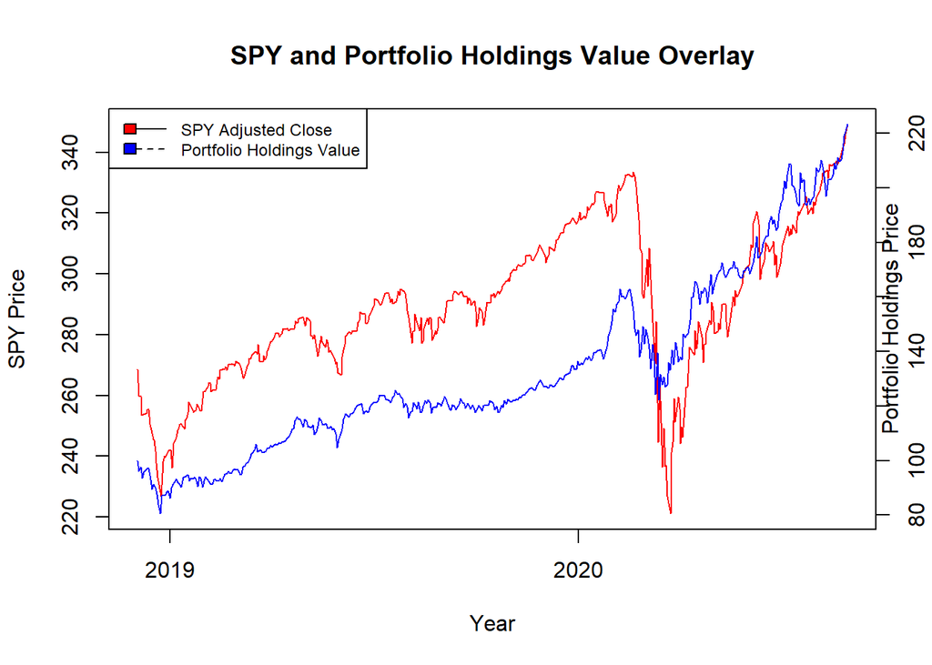

```r
plot(as.zoo(adjSPY1[, "SPY.Adjusted"]), main = "SPY and Portfolio Holdings Value Overlay",
     xlab = "Year", ylab = "SPY Price", col = "Red")

par(new=TRUE)

plot(holdings[, 1], type="line", xaxt="n", yaxt = "n", xlab = "", ylab = "", col = "Blue")
axis(4)
mtext("Portfolio Holdings Price", side = 4)

# Add legend
legend("topleft", c("SPY Adjusted Close", "Portfolio Holdings Value"), lty = 1:3, cex = 0.75, fill = c("red", "blue"))
```

**Remarks**  
**1. Seasonal Trend:**  
Both display similar seasonal trend with up and down spikes in price days after days.  
**2. Cyclical Trend:**  
Both is affected by business cycle with similar peaks and troughs. SPY has more prominent troughs compared to that of the portfolio holdings. Especially during the period of March 2020 with the COVID-19 lockdowns started rolling across the countries.  
**3. Auto-correlation:**  
Both behave similar in this regard where both rises for some times when they rise and vice versa.  
**4. Randomness:**  
Price of both is unpredictable via inspection.  
**5. Time:**  
Both follows similar time trend.  
**6. Structural Break:**  
Both does not experience any structural break during this time frame. During the COVID-19 March sell-off, price recovered quickly in a V-shaped fashion.  
**7. Outliers:**  
SPY looks to have several outliers corresponded to the March 2020 sell-off when the indicies retreated 30% in a short period of a few weeks before quickly recovered.

## 4) Forecast the returns of the portfolio based on the CAPM model

Question covered: (10,11,12)  
**Methodology** 10) Using the CAPM equation of your portfolio do two periods ex-post forecasting of the returns to your portfolio and compare your forecast to the actual returns. Find the accuracy statistics of your forecast and report them.  
11) Do two-periods ex-ante forecasting of returns to your portfolio assuming that the monthly risk premiums to S&P 500 will be 1.10% in 2020M9 and 1.25 in 2020M10.  
12) Do forecasting of the returns to your portfolio for the period 2014M1-2020M8. Find the accuracy statistics of your forecast. Do a naïve forecasting of the returns to your portfolio for the period 2014M1-2020M8. Find the accuracy statistics of your forecast. Compare the forecasting accuracy criterion for the two forecasting methods. Which one results in a better forecasting outcome?

### 10) Using the CAPM equation of your portfolio do two periods ex-post forecasting of the returns to your portfolio and compare your forecast to the actual returns. Find the accuracy statistics of your forecast and report them.

Rerun the regression with the whole data set from 2018M12 to 2020M10:

```r
# Set start date and end date of data
start_date2 <- "2018-12-01"
end_date2 <- "2020-10-31"

# Get data
getSymbols("MSFT", src = "yahoo", from = start_date2, to = end_date2)
```

```
## [1] "MSFT"
```

```r
getSymbols("GWPH", src = "yahoo", , from = start_date2, to = end_date2)
```

```
## [1] "GWPH"
```

```r
getSymbols("DIS", src = "yahoo", , from = start_date2, to = end_date2)
```

```
## [1] "DIS"
```

```r
getSymbols("CAT", src = "yahoo", , from = start_date2, to = end_date2)
```

```
## [1] "CAT"
```

```r
getSymbols("AMZN", src = "yahoo", , from = start_date2, to = end_date2)
```

```
## [1] "AMZN"
```

```r
getSymbols("^GSPC", src = "yahoo", , from = start_date2, to = end_date2) # S&P 500
```

```
## [1] "^GSPC"
```

```r
getSymbols("^TNX", src = "yahoo", from=start_date2, to=end_date2) # TNX (10-year T-bill)
```

```
## [1] "^TNX"
```

```r
rMSFT2 <- diff(log(to.monthly(MSFT)$MSFT.Adjusted))
rGWPH2 <- diff(log(to.monthly(GWPH)$GWPH.Adjusted))
rDIS2 <- diff(log(to.monthly(DIS)$DIS.Adjusted))
rCAT2 <- diff(log(to.monthly(CAT)$CAT.Adjusted))
rAMZN2 <- diff(log(to.monthly(AMZN)$AMZN.Adjusted))
rGSPC2 <- diff(log(to.monthly(GSPC)$GSPC.Adjusted))
rTNX2 <- to.monthly(TNX)$TNX.Adjusted /1200  # Using monthly rate
rTNX2_day <- TNX$TNX.Adjusted /1200
rTNX2 <- rTNX2[-1,]  # remove missing data due to lagging

# Adjusted Prices
adjMSFT2 <- MSFT$MSFT.Adjusted
adjGWPH2 <- GWPH$GWPH.Adjusted
adjDIS2 <- DIS$DIS.Adjusted
adjCAT2 <- CAT$CAT.Adjusted
adjAMZN2 <- AMZN$AMZN.Adjusted
adjGSPC2 <- GSPC$GSPC.Adjusted

holdings2 <- data.frame("Holding Value"=sharesMSFT*adjMSFT2 +
                                       sharesGWPH*adjGWPH2 +
                                       sharesDIS*adjDIS2 +
                                       sharesCAT*adjCAT2 +
                                       sharesAMZN*adjAMZN2)
names(holdings2)[1] <- "Port. Holdings Val"  # rename column

# Calculate and normalized the CAPM holdings
ra2 <- diff(log(to.monthly(holdings2)[,1]))

Y_data <- na.omit(ra - rTNX2)
names(Y_data)[1] <- "Port. Risk. Prem."
X_data <- na.omit(rGSPC2 - rTNX2)
names(X_data)[1] <- "Mrkt. Risk. Prem."
# Market risk premium
data <- data.frame(Y_data, X_data)
names(data)[1] <- "Port. Risk. Prem."
names(data)[2] <- "Mrkt. Risk. Prem."
```

Do the ex-post forecast:

```r
fit_expost <- lm(Y_data~X_data, data)
fit_expost
```

```
##
## Call:
## lm(formula = Y_data ~ X_data, data = data)
##
## Coefficients:
## (Intercept)       X_data
##      0.0294      -0.1985
```

```r
pred_expost <- predict(fit_expost, data)
pred_expost
```

```
##    Jan 2019    Feb 2019    Mar 2019    Apr 2019    May 2019    Jun 2019
## 0.014801553 0.024035661 0.026275703 0.022162793 0.043266751 0.016500005
##    Jul 2019    Aug 2019    Sep 2019    Oct 2019    Nov 2019    Dec 2019
## 0.027148346 0.033277459 0.026298421 0.025667607 0.023048641 0.024124368
##    Jan 2020    Feb 2020    Mar 2020    Apr 2020    May 2020    Jun 2020
## 0.029978470 0.047033623 0.056057428 0.005796511 0.020718019 0.025893837
##    Jul 2020    Aug 2020    Sep 2020    Oct 2020
## 0.018843081 0.016073153 0.037460709 0.035115960
```

Evaluating the errors:

```r
actual_expost <- data[, "Port. Risk. Prem."]
sqrt(mean((pred_expost - actual_expost)^2))
```

```
## [1] 0.07607907
```

This error value means the model is off by $.0760$ on average. Significant!

Do the ex-ante forecast:

```r
data1 <- data[1:20,]
data2 <- data[21:22,]

fit_exante <- lm(Y_data~X_data, data=data1)
fit_exante
```

```
##
## Call:
## lm(formula = Y_data ~ X_data, data = data1)
##
## Coefficients:
## (Intercept)       X_data
##      0.0294      -0.1985
```

```r
pred_exante <- predict(fit_exante, newdata=data2)
pred_exante
```

```
##           1           2           3           4           5           6
## 0.014801553 0.024035661 0.026275703 0.022162793 0.043266751 0.016500005
##           7           8           9          10          11          12
## 0.027148346 0.033277459 0.026298421 0.025667607 0.023048641 0.024124368
##          13          14          15          16          17          18
## 0.029978470 0.047033623 0.056057428 0.005796511 0.020718019 0.025893837
##          19          20          21          22
## 0.018843081 0.016073153 0.037460709 0.035115960
```

Evaluating the errors:

```r
actual_exante <- data[21:22, "Port. Risk. Prem."]
sqrt(mean((pred_exante - actual_exante)^2))
```

```
## [1] 0.1043799
```

This error value means the model is off by $.1044$ on average. Even more significant than the ex-post forecast.

Run a naive forecasting $error = Y_t - Y_{t-1}$:

```r
# Naive forecasting
error <- diff(Y_data)
error
```

```
##          Port. Risk. Prem.
## Jan 2019                NA
## Feb 2019       0.130407624
## Mar 2019       0.052833381
## Apr 2019       0.012097574
## May 2019       0.004786171
## Jun 2019      -0.163247376
## Jul 2019       0.211072656
## Aug 2019      -0.117627551
## Sep 2019      -0.021790003
## Oct 2019       0.004055114
## Nov 2019       0.021229597
## Dec 2019       0.028332669
## Jan 2020       0.026380169
## Feb 2020       0.029152706
## Mar 2020      -0.110675000
## Apr 2020      -0.079707917
## May 2020       0.257338225
## Jun 2020      -0.113316970
## Jul 2020       0.081771690
## Aug 2020      -0.070349143
## Sep 2020      -0.181111949
## Oct 2020       0.130318457
```

The $\epsilon$ residual of regression is:

```r
fit_exante$residuals
```

```
##     Jan 2019     Feb 2019     Mar 2019     Apr 2019     May 2019     Jun 2019
## -0.133331936 -0.012158420  0.038434919  0.054645403  0.038327616 -0.098153014
##     Jul 2019     Aug 2019     Sep 2019     Oct 2019     Nov 2019     Dec 2019
##  0.102271302 -0.021485363 -0.036296329 -0.031610400 -0.007761836  0.019495106
##     Jan 2020     Feb 2020     Mar 2020     Apr 2020     May 2020     Jun 2020
##  0.040021172  0.052118725 -0.067580080 -0.097027080  0.145389637  0.026896849
##     Jul 2020     Aug 2020     Sep 2020     Oct 2020
##  0.115719294  0.048140079 -0.154359426 -0.021696219
```

As discussed above, ex-post (in-sample) forecasting yields a better forecast outcome with lower error.

The Mean Absolute Percent Error statistics:

$$\begin{equation}
\begin{aligned}
MAPE & = \frac{\sum \left\lvert \frac{\epsilon_t}{Y_t} \right\rvert}{n} \\
& = 0.9845165 \\
\end{aligned}
\end{equation}$$

The Real Mean Squared Error statistics:
$$\begin{equation}
\begin{aligned}
RMSE & = \sqrt{\frac{\sum \epsilon^2}{n}} \\
& = 0.0760791
\end{aligned}
\end{equation}$$

# Citations

“Amazon.com, Inc. (AMZN) Stock Price, News, Quote & History.” Yahoo! Finance, Yahoo!, 14 Nov. 2020, ca.finance.yahoo.com/quote/amzn/?p=amzn.

“Caterpillar, Inc. (CAT) Stock Price, News, Quote & History.” Yahoo! Finance, Yahoo!, 13 Nov. 2020, ca.finance.yahoo.com/quote/CAT/?p=CAT.

JeffCoxCNBCcom. “Fed Hikes Rate, Lowers 2019 Projection to 2 Increases.” CNBC, CNBC, 19 Dec. 2018, www.cnbc.com/2018/12/19/fed-hikes-rates-by-a-quarter-point-.html.

“GW Pharmaceuticals Plc (GWPH) Stock Price, News, Quote & History.” Yahoo! Finance, Yahoo!, 13 Nov. 2020, ca.finance.yahoo.com/quote/GWPH/?p=GWPH.

Moyer, Liz. “We’re Finding out Now Why the Stock Market Tanked in December.” CNBC, CNBC, 9 Jan. 2019, www.cnbc.com/2019/01/09/markets-december-tumble-may-have-hinted-at-profit-revisions-to-come.html.

“Microsoft Corporation (MSFT) Stock Price, News, Quote & History.” Yahoo! Finance, Yahoo!, 14 Nov. 2020, ca.finance.yahoo.com/quote/msft/?p=msft.

“Walt Disney Company (The) (DIS) Stock Price, News, Quote & History.” Yahoo! Finance, Yahoo!, 14 Nov. 2020, ca.finance.yahoo.com/quote/dis/?p=dis.